# Data Analysis Tasks(Level-1)

**Note:** If you face any issues with file reading, please change the `file_path` variable based on the location of your data file on your system.

```python
import pandas as pd
import matplotlib.pyplot as plt
```

```python
file_path = r'C:\Users\Akshit Sajwan\Desktop\Cognifyz_Internship\Working Zone\DATA ANALYSIS TASK LIST AND DATASET\internship_tasks\dataset\dataset.csv'
```

```python
df=pd.read_csv(file_path)
df.head()
```

|  | Restaurant ID | Restaurant Name | Country Code | City | Address | Locality | Locality Verbose | Longitude | Latitude | Cuisines | ... | Currency | Has Table booking | Has Online delivery | Is delivering now | Switch to order menu | Price range | Aggregate rating | Rating color | Rating text | Votes |
| --- | --- | --- | --- | --- | --- | --- | --- | --- | --- | --- | --- | --- | --- | --- | --- | --- | --- | --- | --- | --- | --- |
| 0 | 6317637 | Le Petit Souffle | 162 | Makati City | Third Floor, Century City Mall, Kalayaan Avenu... | Century City Mall, Poblacion, Makati City | Century City Mall, Poblacion, Makati City, Mak... | 121.027535 | 14.565443 | French, Japanese, Desserts | ... | Botswana Pula(P) | Yes | No | No | No | 3 | 4.8 | Dark Green | Excellent | 314 |
| 1 | 6304287 | Izakaya Kikufuji | 162 | Makati City | Little Tokyo, 2277 Chino Roces Avenue, Legaspi... | Little Tokyo, Legaspi Village, Makati City | Little Tokyo, Legaspi Village, Makati City, Ma... | 121.014101 | 14.553708 | Japanese | ... | Botswana Pula(P) | Yes | No | No | No | 3 | 4.5 | Dark Green | Excellent | 591 |
| 2 | 6300002 | Heat - Edsa Shangri-La | 162 | Mandaluyong City | Edsa Shangri-La, 1 Garden Way, Ortigas, Mandal... | Edsa Shangri-La, Ortigas, Mandaluyong City | Edsa Shangri-La, Ortigas, Mandaluyong City, Ma... | 121.056831 | 14.581404 | Seafood, Asian, Filipino, Indian | ... | Botswana Pula(P) | Yes | No | No | No | 4 | 4.4 | Green | Very Good | 270 |
| 3 | 6318506 | Ooma | 162 | Mandaluyong City | Third Floor, Mega Fashion Hall, SM Megamall, O... | SM Megamall, Ortigas, Mandaluyong City | SM Megamall, Ortigas, Mandaluyong City, Mandal... | 121.056475 | 14.585318 | Japanese, Sushi | ... | Botswana Pula(P) | No | No | No | No | 4 | 4.9 | Dark Green | Excellent | 365 |
| 4 | 6314302 | Sambo Kojin | 162 | Mandaluyong City | Third Floor, Mega Atrium, SM Megamall, Ortigas... | SM Megamall, Ortigas, Mandaluyong City | SM Megamall, Ortigas, Mandaluyong City, Mandal... | 121.057508 | 14.584450 | Japanese, Korean | ... | Botswana Pula(P) | Yes | No | No | No | 4 | 4.8 | Dark Green | Excellent | 229 |

5 rows × 21 columns

# Task 1: Top Cuisines

1. Determine the top three most common cuisines in the dataset.
2. Calculate the percentage of restaurants that serve each of the top cuisines.

```python
cuisine_s=df['Cuisines'].dropna().str.split(',')
cuisine_exp=cuisine_s.explode()
```

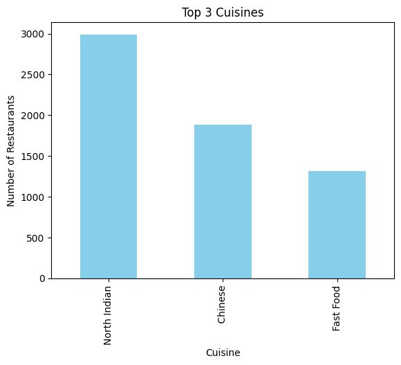

```python
top_cuisines = cuisine_exp.value_counts().head(3)
top_cuisines.plot(kind='bar', color='skyblue')
plt.title('Top 3 Cuisines')
plt.xlabel('Cuisine')
plt.ylabel('Number of Restaurants')
plt.show()
```

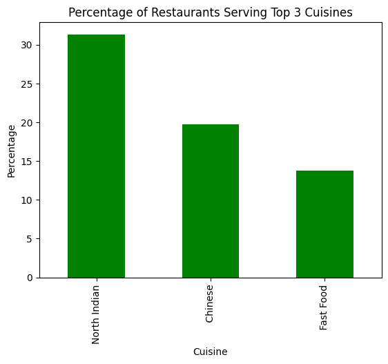

```python
total_restaurants = len(df)
cuisines_percentage=(top_cuisines/total_restaurants)*100
cuisines_percentage.plot(kind='bar', color='green')
plt.title('Percentage of Restaurants Serving Top 3 Cuisines')
plt.xlabel('Cuisine')
plt.ylabel('Percentage')
plt.show()
```

```python
cuisines_percentage
```

```
Cuisines
North Indian    31.326563
 Chinese        19.683803
 Fast Food      13.757722
Name: count, dtype: float64
```

## Conclusion

- *The top three most common cuisines in the dataset are:North Indian, Chinese, Fast Food*
- *the percentage of restaurants that serve each of the top cuisines are: 31.326563, 19.683803, 13.757722*

# Task 2: City Analysis

1. Identify the city with the highest number of restaurants in the dataset.
2. Calculate the average rating for restaurants in each city.
3. Determine the city with the highest average rating.

```python
city_counts=df['City'].value_counts()
top_city=city_counts.idxmax()
print("The city with the highest number of restaurants in the dataset is "+ top_city)
```

```
The city with the highest number of restaurants in the dataset is New Delhi
```

```python
city_avg_rating=df.groupby('City')['Aggregate rating'].mean()
print(r"The average rating for restaurants in each city are following:\n"+ city_avg_rating.head().to_string())
```

```
The average rating for restaurants in each city are following:\nCity
Abu Dhabi    4.300000
Agra         3.965000
Ahmedabad    4.161905
Albany       3.555000
Allahabad    3.395000
```

```python
highest_avg_rating= city_avg_rating.sort_values(ascending=False).head(1)
print("The city with the highest average restaurant rating is:\n"+highest_avg_rating.to_string())
```

```
The city with the highest average restaurant rating is:
City
Inner City    4.9
```

## Conclusion

- *The city with the highest number of restaurants in the dataset is:"New Delhi"*
- *The average rating for restaurants in each city are following specified above.*
- *The city with the highest average rating in dataset is: "Inner City with 4.9"*

# Task 3: Price Range Distribution

1. Create a histogram or bar chart to visualize the distribution of price ranges among the restaurants.
2. Calculate the percentage of restaurants in each price range category.

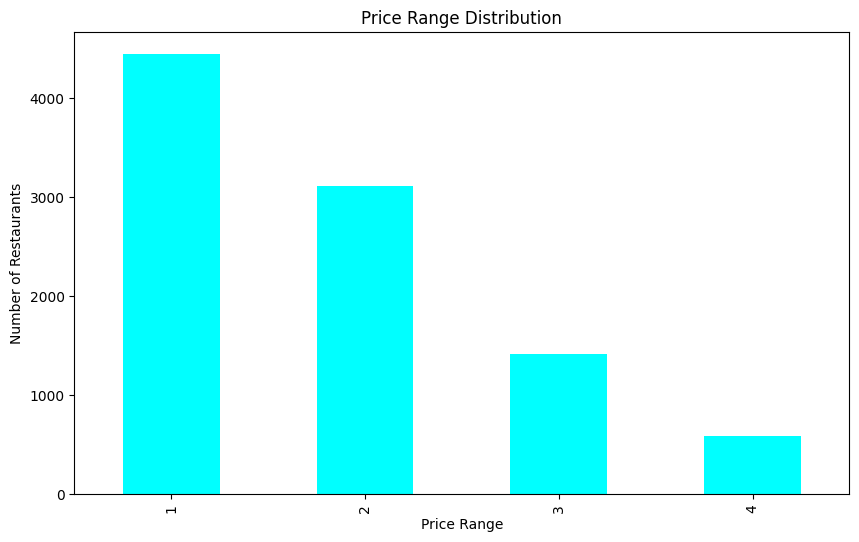

```
Price range
1    4444
2    3113
3    1408
4     586
Name: count, dtype: int64
```

```python
price_range_counts= df['Price range'].value_counts().sort_index()

plt.figure(figsize=(10, 6))
price_range_counts.plot(kind='bar', color='cyan')
plt.title('Price Range Distribution')
plt.xlabel('Price Range')
plt.ylabel('Number of Restaurants')
plt.show()

price_range_counts
```

```python
price_range_percentage=(price_range_counts/total_restaurants)*100
print("The percentage of restaurants in each price range category\n"+price_range_percentage.to_string())
```

```
The percentage of restaurants in each price range category
Price range
1    46.529159
2    32.593446
3    14.741912
4     6.135483
```

## Conclusion

- *Create a histogram or bar chart to visualize the distribution of price ranges among the restaurants are specified above.*
- *The percentage of restaurants in each price range category is 46.529159, 32.593446, 14.741912, 6.135483*

# Task 4: Online Delivery

1. Determine the percentage of restaurants that offer online delivery.
2. Compare the average ratings of restaurants with and without online delivery.

```python
online_delivery_counts=df['Has Online delivery'].value_counts()
online_delivery_percent=(online_delivery_counts['Yes']/total_restaurants)*100
print("The total percentage of restaurants that offer online delivery is\n" + str(online_delivery_percent))
```

```
The total percentage of restaurants that offer online delivery is
25.662234321013504
```

```python
avg_rating_online_delivery=df[df['Has Online delivery']=='Yes']['Aggregate rating'].mean()
avg_rating_no_online_delivery=df[df['Has Online delivery']=='No']['Aggregate rating'].mean()
```

```python
ratings_comparison = pd.Series([avg_rating_online_delivery, avg_rating_no_online_delivery], index=['With Online Delivery', 'Without Online Delivery'])
print("The average ratings of restaurants with and without online delivery:\n"+ratings_comparison.to_string())
```

```
The average ratings of restaurants with and without online delivery:
With Online Delivery       3.248837
Without Online Delivery    2.465296
```

## Conclusion

- *The total percentage of restaurants that offer online delivery is

`25.662234321013504`*

- *The average ratings of restaurants with and without online delivery:

`With Online Delivery: 3.248837` and `Without Online Delivery: 2.465296`*